# RBIF111 Week 10 Final

Author: Laura Wooten

Last update: 09 June, 2025

**Import Data**

```r
pData <- read.csv("~/Documents/RBIF111/wk10-Final/TCGA_BRCA_clinical_data.csv", row.names=1)
eData <- read.csv("~/Documents/RBIF111/wk10-Final/TCGA_BRCA_mRNA_expression.csv", row.names=1)
```

# 1 QUESTION 1:

**10 points Please construct a linear regression model with ER IHC (ER_Status_By_IHC) as the input and “overall survival months” as the output. Calculate the 95% confidence interval for the regression coefficients. Explain the coefficients, their 95% CI, and the associated p-value for TMB. (Only consider IHC positive and negative records, and remove NA, and indeterminate records).**

## 1.1 Filter data and view distribution of OSM by ER status

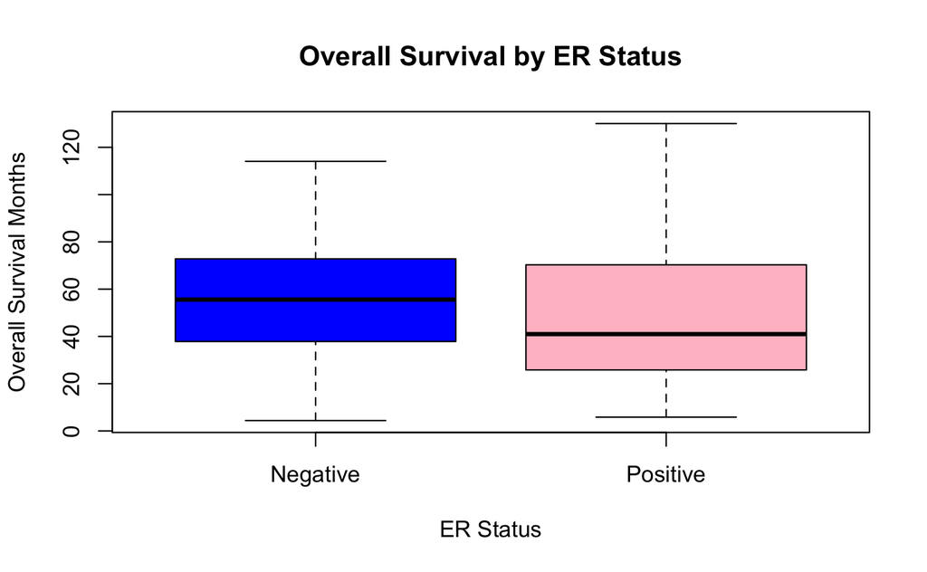

```r
#filter df to be rows where ER_statue is Pos/Neg only, select columns ER/Overall survival months
ers.osm.df <- pData[pData$ER_Status_By_IHC %in% c("Positive", "Negative") &
                      !is.na(pData$Overall_Survival_Months) &
                      !is.na(pData$TMB_nonsynonymous),
                    c("ER_Status_By_IHC", "Overall_Survival_Months", "TMB_nonsynonymous")]
colnames(ers.osm.df) <- c("ER", "OSM", "TMB")
#categorical variable to factor for linear modeling
ers.osm.df$ER <- as.factor(ers.osm.df$ER)

#-----VIEW DISTRIBUTION OF OSM ACROSS ER GROUPS-------
# Boxplot
boxplot(OSM ~ ER, data=ers.osm.df,
        main="Overall Survival by ER Status",
        ylab="Overall Survival Months",
        xlab="ER Status",
        col=c("blue", "pink"))
```

After filtering the data set to only include rows where ER ICH has positive and negative records, as well as removing rows where overall survival months (OSM) or TMB have NA values, I wanted to take a peek at the distribution of OSM stratified by ER ICH. The boxplot shows that the median OSM was slightly higher in ER-negative patients, but there is a lot of overlap between the distributions, suggesting that ER ICH alone may not be a strong predictor of survival.

## 1.2 Construct linear models +/- TMB

I constructed two linear models based on your feedback by email. The first takes ER ICH alone as the independent variable for the outcome of OSM, the second includes TMB as an additional independent variable.

```r
#linear regression: Independent: ER status by ICH (categorical/binary) + TMB (continuous), Dependent: Overall survival rate (continuous)
#Quantifies the effect of only ER on OSM
x1.lm <- lm(OSM~ER, ers.osm.df)
# Quantifies the effect of both ER and TMB on OSM.
x2.lm <- lm(OSM~ER + TMB, ers.osm.df)

#summary of lms
summary(x1.lm)
```

```
Call:
lm(formula = OSM ~ ER, data = ers.osm.df)

Residuals:
    Min      1Q  Median      3Q     Max
-52.493 -21.676  -6.014  21.164  81.556

Coefficients:
            Estimate Std. Error t value Pr(>|t|)
(Intercept)   56.893      6.449   8.822 1.14e-13 ***
ERPositive    -8.389      7.283  -1.152    0.253
---
Signif. codes:  0 ‘***’ 0.001 ‘**’ 0.01 ‘*’ 0.05 ‘.’ 0.1 ‘ ’ 1

Residual standard error: 28.11 on 86 degrees of freedom
Multiple R-squared:  0.01519,   Adjusted R-squared:  0.00374
F-statistic: 1.327 on 1 and 86 DF,  p-value: 0.2526
```

```r
summary(x2.lm)
```

```
Call:
lm(formula = OSM ~ ER + TMB, data = ers.osm.df)

Residuals:
    Min      1Q  Median      3Q     Max
-54.423 -20.137  -5.303  19.027  81.960

Coefficients:
            Estimate Std. Error t value Pr(>|t|)
(Intercept)   65.451      7.271   9.001 5.37e-14 ***
ERPositive    -9.313      7.111  -1.310   0.1939
TMB           -4.231      1.806  -2.343   0.0215 *
---
Signif. codes:  0 ‘***’ 0.001 ‘**’ 0.01 ‘*’ 0.05 ‘.’ 0.1 ‘ ’ 1

Residual standard error: 27.41 on 85 degrees of freedom
Multiple R-squared:  0.07492,   Adjusted R-squared:  0.05316
F-statistic: 3.442 on 2 and 85 DF,  p-value: 0.03652
```

```r
#compare lm with/without TMB using anova
anova(x1.lm, x2.lm)
```

```
Analysis of Variance Table

Model 1: OSM ~ ER
Model 2: OSM ~ ER + TMB
  Res.Df   RSS Df Sum of Sq      F  Pr(>F)
1     86 67963
2     85 63841  1    4122.3 5.4886 0.02148 *
---
Signif. codes:  0 ‘***’ 0.001 ‘**’ 0.01 ‘*’ 0.05 ‘.’ 0.1 ‘ ’ 1
```

```r
# Scatterplot: TMB vs Overall Survival Months, colored by ER status
plot(ers.osm.df$TMB, ers.osm.df$OSM,
     col=as.numeric(ers.osm.df$ER),
     pch=19,
     xlab="TMB (nonsynonymous)",
     ylab="Overall Survival Months",
     main="TMB vs Overall Survival Months")
legend("topright", legend=levels(ers.osm.df$ER),
       col=("black", "red"), pch=19, title="ER Status")
```

[output not shown]

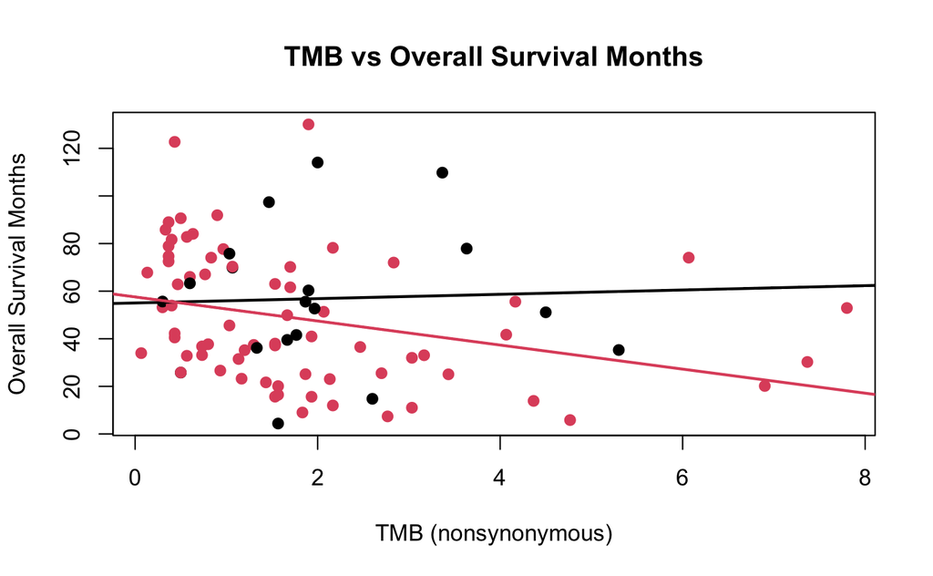

```r
# Add regression lines for each ER group
for (lev in levels(ers.osm.df$ER)) {
  idx <- ers.osm.df$ER == lev
  abline(lm(OSM ~ TMB, data=ers.osm.df[idx,]), col=which(levels(ers.osm.df$ER)==lev), lwd=2)
}
```

The linear regression for OSM ~ ER (`x1.lm`) shows that average survival for ER ICH negative patients is 56.9 months (intercept). The coefficient for `ERPositive` is -8.389, which we can interperet as ER ICH positive patients have approximately 8.4 months less survival in comparison, however, the p-value for this coefficient is 0.253. Therefore we accept the null hypothesis on this test that states there is no significant difference in overall survival between ER ICH patients. Supporting this, the R-squared value is very low (0.015) which means this regression model explains very little variance in the data.

The second model (`x2.lm`) includes TMB as an additional variable. Here we see that average survival for ER ICH patients is 65.5 months, and the estimated coeffients for `ERPositive` and `TMB` are -9.313 and -4.231, respectively. Again the p-value associated with the coefficient for `ERPositive` is above the cutoff of 0.05, meaning that it is still not significant after adjusting for TMB. However, the `TMB` coefficient has a p-value of 0.0215, which means TMB is a significant predictor of overall survival. Here we can interpret this to mean that for each unit increase of TMB we see survival drop by 4.2 months. The R-squared value is still very low (0.075) meaning that even with this additional predictor, the model still doesn’t explain much of the variance.

The ANOVA was somewhat unnecessary, but it highlights that adding TMB to the model significantly improved the fit (F=5.49, p=0.0215). I wanted to visualize the second model, and went with a scatter plot of TMB vs overall survival months, colored by ER ICH status. The regression line for ERNegative (black) is mostly flat, which suggests that as TMB increases there is no affect on OSM (no association). The red regression line (ERPositive) has a negative slope, showing that as TMB increases OSM decreases. Although there’s a large spread of survival months at each TMB value, I think the trend for ERPositive is pretty clear.

## 1.3 Calculate Confidence Intervals and plot

```r
#-----------calc 95 CIs----------
x1.ci <- confint(x1.lm); x1.ci
```

```
                2.5 %    97.5 %
(Intercept)  44.07240 69.713919
ERPositive  -22.86754  6.089924
```

```r
x2.ci <- confint(x2.lm); x2.ci
```

```
                 2.5 %    97.5 %
(Intercept)  50.993463 79.908569
ERPositive  -23.452253  4.826169
TMB          -7.821197 -0.640172
```

```r
# Extract coefficients and CIs for both models
coefs1 <- coef(x1.lm)
ci1 <- confint(x1.lm)
df1 <- data.frame(
  term = names(coefs1),
  estimate = coefs1,
  lower = ci1[, 1],
  upper = ci1[, 2],
  model = "ER only"
)

coefs2 <- coef(x2.lm)
ci2 <- confint(x2.lm)
df2 <- data.frame(
  term = names(coefs2),
  estimate = coefs2,
  lower = ci2[, 1],
  upper = ci2[, 2],
  model = "ER + TMB"
)

# Combine
ci_df <- rbind(df1, df2)
ci_df$term_model <- paste(ci_df$term, ci_df$model, sep=": ")

# Plot
plot(1:nrow(ci_df), ci_df$estimate, ylim = range(ci_df$lower, ci_df$upper),
     pch = 19, xaxt = "n", xlab = "", ylab = "Coefficient Estimate",
     main = "Coefficient Estimates with 95% CI (Both Models)")
arrows(1:nrow(ci_df), ci_df$lower, 1:nrow(ci_df), ci_df$upper,
       angle = 90, code = 3, length = 0.1)
```

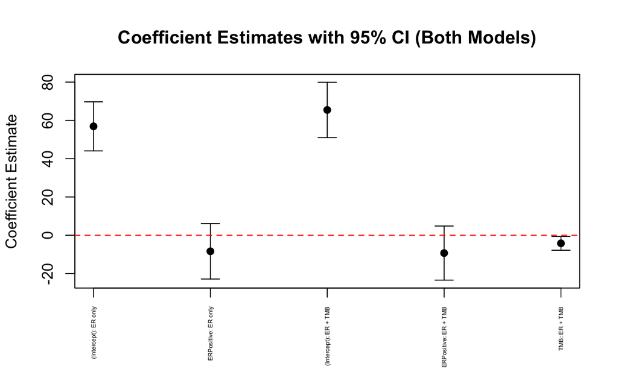

```r
axis(1, at = 1:nrow(ci_df), labels = ci_df$term_model, las=2, cex.axis=0.4)
abline(h = 0, col = "red", lty = 2)
```

The 95% confidence intervals for the regression coefficients show that ER status is not a significant predictor of overall survival, as the interval includes zero in both models. In contrast, TMB is a significant negative predictor in the multiple regression model, with a 95% CI that does not include zero (–7.8 to –0.6). This reiterates that higher TMB is associated with shorter survival.The coefficient plot further illustrates these results, with only the TMB coefficient’s CI not crossing zero. The CI measures the reliability of the estimated coefficients from the model, it states that if we repeated the model with new random samples from the same population many times, 95% of those intervals would contain the true value of the coefficient, so the smaller the interval (as with `TMB: ER + TMB`) the more precice the estimate is.

# 2 QUESTION 2:

**15 points Please construct a cox regression model with ER IHC (ER_Status_By_IHC) as the input and “overall survival months” & “Overall_Survival_Status” as the output. Calculate the 95% Odds ratio for the regression model.Plot the Kaplan-Meier curve. Explain the %95 Odds ratio, and the associated p-value for TMB. (Only consider IHC positive and negative records, and remove NA, and indeterminate records).**

## 2.1 Construct Cox models, Calculate CIs, and plot

```r
library(survival)

#filter data
cox.df <- pData[pData$ER_Status_By_IHC %in% c("Positive", "Negative") &
                  !is.na(pData$Overall_Survival_Months) &
                  !is.na(pData$Overall_Survival_Status) &
                  !is.na(pData$TMB_nonsynonymous),
                c("ER_Status_By_IHC", "Overall_Survival_Months", "Overall_Survival_Status", "TMB_nonsynonymous")]
colnames(cox.df) <- c("ER", "OSM", "Status", "TMB")

#categrorical variable to factor for cox regression
cox.df$ER <- as.factor(cox.df$ER)

#survival status to binary ("1:DECEASED" = 1, "0:LIVING" = 0)
cox.df$Status <- ifelse(cox.df$Status == "1:DECEASED", 1, 0)

#fit cox model ER only
x1.cox <- coxph(Surv(OSM, Status) ~ ER, data = cox.df)
#fit cox ER + TMB
x2.cox <- coxph(Surv(OSM, Status) ~ ER + TMB, data = cox.df)

summary(x1.cox)
```

```
Call:
coxph(formula = Surv(OSM, Status) ~ ER, data = cox.df)

  n= 88, number of events= 33

              coef exp(coef) se(coef)     z Pr(>|z|)
ERPositive 0.07538   1.07829  0.41694 0.181    0.857

           exp(coef) exp(-coef) lower .95 upper .95
ERPositive     1.078     0.9274    0.4762     2.441

Concordance= 0.539  (se = 0.035 )
Likelihood ratio test= 0.03  on 1 df,   p=0.9
Wald test            = 0.03  on 1 df,   p=0.9
Score (logrank) test = 0.03  on 1 df,   p=0.9
```

```r
summary(x2.cox)
```

```
Call:
coxph(formula = Surv(OSM, Status) ~ ER + TMB, data = cox.df)

  n= 88, number of events= 33

              coef exp(coef) se(coef)     z Pr(>|z|)
ERPositive 0.11299   1.11962  0.42489 0.266    0.790
TMB        0.05328   1.05473  0.11764 0.453    0.651

           exp(coef) exp(-coef) lower .95 upper .95
ERPositive     1.120     0.8932    0.4869     2.575
TMB            1.055     0.9481    0.8375     1.328

Concordance= 0.582  (se = 0.059 )
Likelihood ratio test= 0.23  on 2 df,   p=0.9
Wald test            = 0.24  on 2 df,   p=0.9
Score (logrank) test = 0.24  on 2 df,   p=0.9
```

```r
#compare both cox models with anova
anova(x1.cox, x2.cox)
```

```
Analysis of Deviance Table
 Cox model: response is  Surv(OSM, Status)
 Model 1: ~ ER
 Model 2: ~ ER + TMB
   loglik  Chisq Df Pr(>|Chi|)
1 -111.34
2 -111.24 0.1941  1     0.6595
```

```r
#get 95% CIs for hazard ratios
x1.cox.ci <- exp(confint(x1.cox)); x1.cox.ci
```

```
               2.5 %   97.5 %
ERPositive 0.4762474 2.441395
```

```r
x2.cox.ci <- exp(confint(x2.cox)); x2.cox.ci
```

```
               2.5 %  97.5 %
ERPositive 0.4868585 2.57476
TMB        0.8375348 1.32824
```

```r
#-----------COX MODEL CI PLOT -----------
# get coefficients and CIs for both models
coefs1.cox <- exp(coef(x1.cox))
ci1.cox <- exp(confint(x1.cox))
df1.cox <- data.frame(
  term = names(coefs1.cox),
  estimate = coefs1.cox,
  lower = ci1.cox[, 1],
  upper = ci1.cox[, 2],
  model = "ER only"
)

coefs2.cox <- exp(coef(x2.cox))
ci2.cox <- exp(confint(x2.cox))
df2.cox <- data.frame(
  term = names(coefs2.cox),
  estimate = coefs2.cox,
  lower = ci2.cox[, 1],
  upper = ci2.cox[, 2],
  model = "ER + TMB"
)

# Combine
ci_df_cox <- rbind(df1.cox, df2.cox)
ci_df_cox$term_model <- paste(ci_df_cox$term, ci_df_cox$model, sep=": ")

# Plot
plot(1:nrow(ci_df_cox), ci_df_cox$estimate, ylim = range(ci_df_cox$lower, ci_df_cox$upper),
     pch = 19, xaxt = "n", xlab = "", ylab = "Hazard Ratio",
     main = "Hazard Ratios with 95% CI (both models)", log = "y")
arrows(1:nrow(ci_df_cox), ci_df_cox$lower, 1:nrow(ci_df_cox), ci_df_cox$upper,
       angle = 90, code = 3, length = 0.1)
```

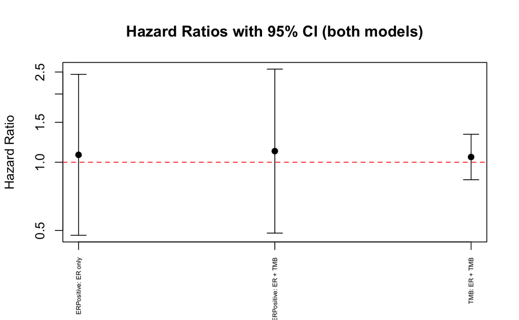

```r
axis(1, at = 1:nrow(ci_df_cox), labels = ci_df_cox$term_model, las=2, cex.axis=0.5)
abline(h = 1, col = "red", lty = 2)
```

```r
NA
NA
NA
```

While the hazard ratios for `ERPositive` in model 1 (ER only), `ERPositive` and `TBM` in model 2 (ER + TMB), were slightly greater than 1, which would indicate a higher risk of death compared to ER ICH negative patients, the associated p-values are all greater than 0.6, meaning that neither of these variables are significant predictors of survival according to the Cox regression. Adding TMB to the model did not improve the models fit (ANOVA p=0.66)

The 95% CIs of all hazard ratios in both models include 1, and we can see in the plot that the intervals are fairly wide. This suggests that there is no statistically significant association between ER ICH status or TMB and OSM in this data set, and that there is a lot of uncertainty in the estimates. As opposed to linear models, CIs in survival analysis are looking at the hazard ratios indicate the risk of an event occurring (death) between groups, with 1 serving as no risk. If the CI includes 1, the predictor is not significant, meaning we cannot determine a meaningful difference in risk.

## 2.2 Survival Plot

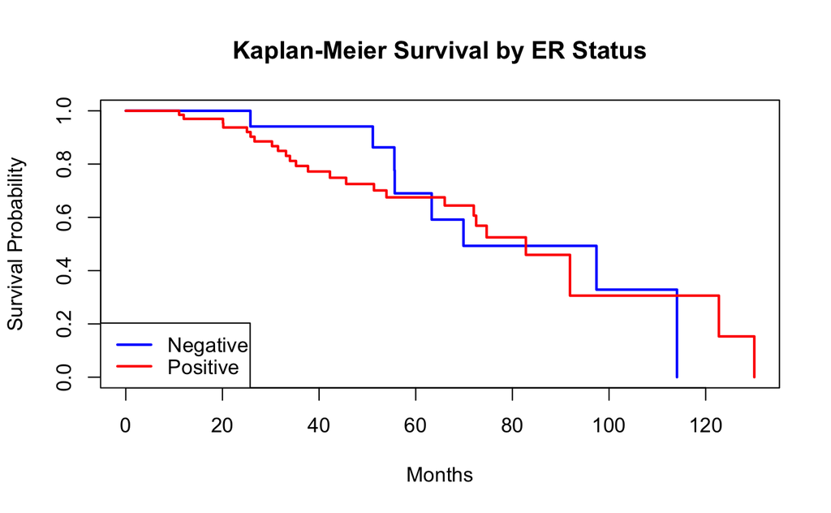

```r
#-----plot KM survival curves by ER status----
surv_obj <- Surv(cox.df$OSM, cox.df$Status)
fit_km <- survfit(surv_obj ~ ER, data = cox.df)
plot(fit_km, col = c("blue", "red"), lwd = 2,
     xlab = "Months", ylab = "Survival Probability",
     main = "Kaplan-Meier Survival by ER Status")
legend("bottomleft", legend = levels(cox.df$ER), col = c("blue", "red"), lwd = 2)
```

The Kaplan_Meier plot shows the survival probability over time for ERNegative (blue) and ERPositive (red) groups. The curves are similar and overlap a lot, which visually supports that there is no significant difference in survival between ER ICH groups. This plot does not include TMB as it is a continuous variable, and KM curves are used to visualize survival probabilites between groups. However, if we wanted to demonstrate this we could split TMB into groups (like high vs low) and then plot the survival by TMB groups.

# 3 QUESTION 3:

**15 points Compare the linear regression model from question 1 with the Cox regression model from question 2. Which model demonstrates higher accuracy? Why is “Overall_Survival_Status” necessary when “overall survival months” already serves as an output?**

Comparing the two approaches, linear regression identified TMB as a significant predictor of overall survival months, while Cox regression did not find either ER status or TMB to be significant predictors of survival time. Although linear regression showed a modest improvement in model fit with TMB, both models had low overall accuracy and explained little variance in the data (low R-squared values). In this case Cox regression is more appropriate for survival data because it accounts for censored observations, which are samples/patients who have not yet experienced the event (death) by the end of the study. This is why “Overall_Survival_Status” is necessary in addition to “overall survival months”, because it creates a survival object that allows the model to distinguish between completed events and censored cases, which gives an accurate estimation of survival risk. Linear regression ignores censoring and treats all survival times as completed events, which can bias the results if many patients are censored, and find relationships in the data that don’t exist.

# 4 QUESTION 4:

35 points Identify the genes most significantly associated with ‘overall survival months’ and ‘Overall_Survival_Status’ in tumor samples. We will employ the holdout method for cross-validation by splitting the dataset into two parts: a training set comprising 60% of the data and a testing set comprising 40%. The model will be trained on the training set, tested on the testing set, and its performance evaluated. To simplify the analysis, we will use the median expression of each gene as a cutoff to categorize patients into high and low expression groups for input. Please write code to calculate p-values between outcomes and all genes in the mRNA expression table using Cox regression. All p-values for each gene need to be saved and corrected for multiple hypothesis testing. Please report the top 5 genes based on p-values in the training set and their corresponding p-values in the testing set. Please save the top 5 genes Kaplan-Meier curves for testing set results.

## 4.1 Select tumor samples only and clean data

```r
#1. select tumor samples only & make sure samples are in the same order in both expression data and clinical data
common.smpls <- intersect(colnames(eData), pData$Sample_ID_Tumor) #restrict samples in eData to only the tumor_samples as listed in pData
texprs <- eData[, common.smpls]
tpdata <- pData[pData$Sample_ID_Tumor==common.smpls,]
rownames(tpdata) <- tpdata$Sample_ID_Tumor #make tumorID the rownames for simplicity

#remove nas, create new columns (status = binary, OSM = survival months) - keep together at end for ease
tpdata <- tpdata[!is.na(tpdata$Overall_Survival_Months) & !is.na(tpdata$Overall_Survival_Status),] #select tumor samples without NA values for the cox survival object
tpdata$STATUS <- ifelse(tpdata$Overall_Survival_Status == "1:DECEASED", 1, 0) #convert whether event of death has occurred from string to binary
tpdata$OSM <- tpdata$Overall_Survival_Months
#subset texprs to match tpdata
texprs <- texprs[,rownames(tpdata)] #if any samples have NA in survival data from clinical dataframe, remove those samples from the expression data.
```

## 4.2 Split into Training/Testing sets

```r
set.seed(1)
train.index <- sample(1:nrow(tpdata), size = 0.6*nrow(tpdata)) #sample without replacement 60% of number of samples - rounds down to whole number
tpdata.train <- tpdata[train.index,] #select rows corresponding to sampled indices
tpdata.test <- tpdata[-train.index,] #select rows not corresponding to sampled indices
texprs.train <- texprs[, rownames(tpdata.train)] #filter expression data to training
texprs.test <- texprs[, rownames(tpdata.test)]
#check to make sure all samples are included
as.numeric(dim(texprs.train)[2]) + as.numeric(dim(texprs.test)[2]) == as.numeric(dim(tpdata)[1])
```

```
[1] TRUE
```

All samples are being accounted for within the training/testing sets

## 4.4 Correct for multple hypothesis testing

```r
pvals.fdr <-  p.adjust(pvals, method = "fdr")
sort(pvals)[1:10]
```

```
      STARD6      FAM138B        HSPB7      BCL2L14       ZNF845        AMAC1     PRAMEF20     HLA-DRB6       SPINK1
3.216698e-05 1.024256e-04 5.095004e-04 6.816001e-04 6.958845e-04 7.515625e-04 8.548465e-04 1.005764e-03 1.105008e-03
      ZNF468
1.185415e-03
```

```r
sort(pvals.fdr)[1:10]
```

```
   STARD6   AADACL3    AARSD1     ABCA1     ABCA7     ABCB5    ABCC10     ABCC4     ABCC9     ABCD2
0.6363915 0.8434066 0.8434066 0.8434066 0.8434066 0.8434066 0.8434066 0.8434066 0.8434066 0.8434066
```

You can see that after using a FDR correction, my top gene is still present, however all genes afterwards appear in alphabetical order. I tried looking into this best I could and found that when perfomring thousands of statistical tests, the FDR correction adjusts p-values with the aim of controlling for false positives. However if none of the raw p-values are particularly small, the adjustment can assign the same adjusted p-value to many genes. Therefore, when the genes are sorted by adjusted p-value, the top genes will appear in alphabetical order if their values are the same. From my understanding this happens because the FDR method is based on rank, so when many p-values are similar (and the number of tests is in the thousands) their adjusted values become identical and can lead to ties. After our correspondence I implemented your suggestions, please see below.

1. DO AADACL3, AARSDI, ABCA1, ABCA7 ETC HAVE THE SAME UNCORRECTED PVALS?

```r
sort(pvals.fdr)[2:10]
```

```
  AADACL3    AARSD1     ABCA1     ABCA7     ABCB5    ABCC10     ABCC4     ABCC9     ABCD2
0.8434066 0.8434066 0.8434066 0.8434066 0.8434066 0.8434066 0.8434066 0.8434066 0.8434066
```

```r
A.names <- names(sort(pvals.fdr)[2:10])
pvals[A.names]
```

```
    AADACL3      AARSD1       ABCA1       ABCA7       ABCB5      ABCC10       ABCC4       ABCC9       ABCD2
0.008506895 0.157329817 0.046510555 0.148080390 0.060291821 0.015702401 0.046237593 0.038086552 0.091874220
```

Although the raw p-values for many genes are different, the FDR correction can assign the same adjusted p-value to multiple genes because the adjustment is based on the rank and total number of tests, and when most p-values are not very small, the correction flattens the adjusted values and can result in ties [1].

2. TRY DIFFERENT FUNCTION TO CALCULATE FDR -> QVALUE

```r
library(qvalue)
q <- qvalue(pvals)
qvals <- q$qvalues

# Top 5 genes by q-value
sort(qvals)[1:10]
```

```
   STARD6   AADACL3    AARSD1     ABCA1     ABCA7     ABCB5    ABCC10     ABCC4     ABCC9     ABCD2
0.6363915 0.8434066 0.8434066 0.8434066 0.8434066 0.8434066 0.8434066 0.8434066 0.8434066 0.8434066
```

```r
names(sort(qvals))[1:5]
```

```
[1] "STARD6"  "AADACL3" "AARSD1"  "ABCA1"   "ABCA7"
```

Same result as using `p.adjust()`.

3. TRY BONFERRONI CORRECTION ON PVALS.

```r
pvals.bon <- p.adjust(pvals, method = "bonferroni")
sort(pvals.bon)[1:10]
```

```
   STARD6      A1BG      A1CF     A2BP1     A2LD1     A2ML1       A2M    A4GALT     A4GNT      AAA1
0.6363915 1.0000000 1.0000000 1.0000000 1.0000000 1.0000000 1.0000000 1.0000000 1.0000000 1.0000000
```

All genes other than STARD6 now have an adjusted value of 1.

Based on these results, no genes reached significance after FDR or Bonferroni correction. While I will continue to report their corrected pvalues alongside raw values downstream, I will be proceeding with the top 5 genes based on raw p-values for this analysis, knowing that the results of this anaysis would need to be interpreted with caution as they don’t meed significance thresholds after multiple testing correction. Upon looking into this further I found that this is an acceptable method for data exploration, with the caveat that validation is needed [2].

## 4.5 Select top5 genes for model testing

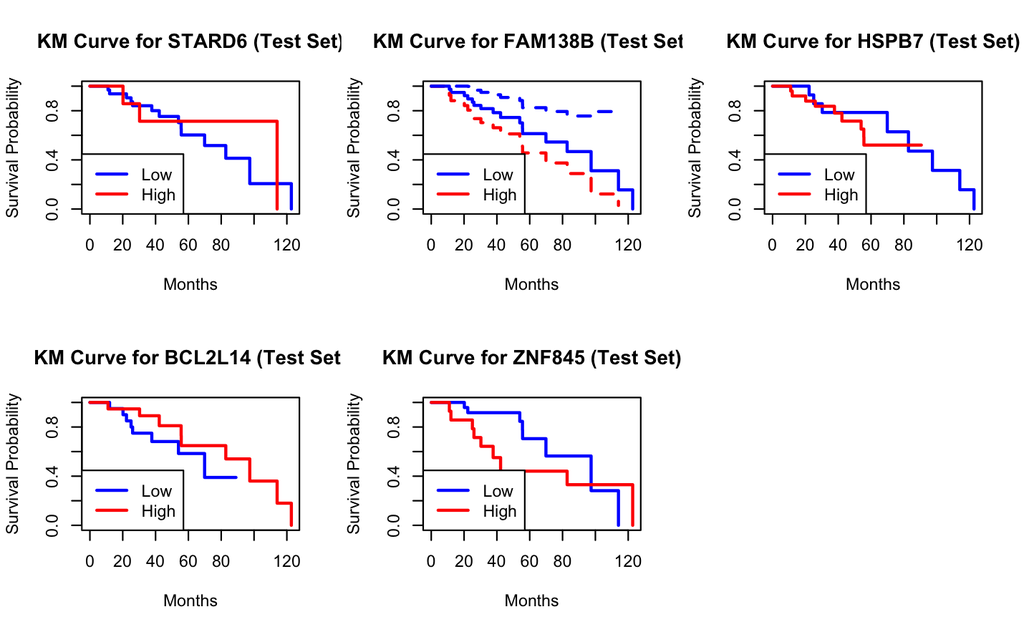

```r
#4. select top 5 uncorrected - proceed with test set
top5 <- names(sort(pvals)[1:5])

#5 use these top genes in testing set data + plot KM curves
texprs.test <- texprs.test[, rownames(tpdata.test)]
pvals.test <- c()
oldpar <- par(mfrow = c(2,3))
for (gene in top5){
  median <- median(as.numeric(texprs.train[gene,]), na.rm = TRUE) #still use training median - dont let model see new data
  label.test <- ifelse(texprs.test[gene,] > median, "high", "low")
  label.test <- factor(label.test, levels = c("low", "high"))
  cox.test <- coxph(Surv(tpdata.test$OSM, tpdata.test$STATUS)~label.test)
  pvals.test[gene] <- summary(cox.test)$coefficients[1,5]

  #plot
  plot(survfit(Surv(tpdata.test$OSM, tpdata.test$STATUS)~label.test),
       col = c("blue", "red"), lwd = 2,
       main = paste("KM Curve for", gene, "(Test Set)"),
       xlab = "Months", ylab = "Survival Probability")
  legend("bottomleft", legend = c("Low", "High"), col = c("blue", "red"), lwd = 2)
}
par(oldpar)
```

```r
pvals.test
```

```
   STARD6   FAM138B     HSPB7   BCL2L14    ZNF845
0.8477792        NA 0.7044016 0.2986264 0.1890585
```

```r
pval.df <- data.frame(train= pvals[top5], train.fdr=pvals.fdr[names(pvals[top5])], test= pvals.test[names(pvals[top5])])
pval.df
```

|  | train | train.fdr | test |
| --- | --- | --- | --- |
| STARD6 | 3.216698e-05 | 0.6363915 | 0.8477792 |
| FAM138B | 1.024256e-04 | 0.8434066 | NA |
| HSPB7 | 5.095004e-04 | 0.8434066 | 0.7044016 |
| BCL2L14 | 6.816001e-04 | 0.8434066 | 0.2986264 |
| ZNF845 | 6.958845e-04 | 0.8434066 | 0.1890585 |

# 5 QUESTION 5:

25 points Find a breast cancer dataset containing gene expression and survival data; cbioportal (https://www.cbioportal.org/) is a good starting point. Test the top 5 genes identified in question 4 and report whether high or low expression of each gene is associated with overall survival. Please save the top 5 genes Kaplan-Meier curves for this external validation results.

## 5.2 Apply Cox regression and Plot

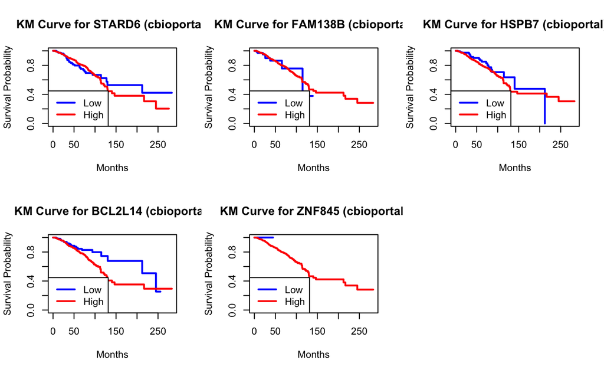

```r
pvals.cbio <- c()
oldpar <- par(mfrow= c(2,3))
for (gene in top5) {
  # Use the training set median for this gene
  train.median <- median(as.numeric(texprs.train[gene, ]), na.rm = TRUE)
  exprs.cbio <- as.numeric(cbio.5[gene, ])
  labels.cbio <- ifelse(exprs.cbio > train.median, "high", "low") #for all 1082 samples
  #labels.cbio <- factor(labels.cbio, levels = c("low", "high"))

  # Only run if both groups are present
  if (length(unique(labels.cbio)) < 2) {
    pvals.cbio[gene] <- NA
    next
  }

  cox.cbio <- coxph(Surv(cbio.pdata$OSM, cbio.pdata$STATUS) ~ labels.cbio)
  pvals.cbio[gene] <- summary(cox.cbio)$coefficients[1, 5]

  # Plot KM curve
  plot(survfit(Surv(cbio.pdata$OSM, cbio.pdata$STATUS) ~ labels.cbio),
       col = c("blue", "red"), lwd = 2,
       main = paste("KM Curve for", gene, "(cbioportal)"),
       xlab = "Months", ylab = "Survival Probability")
  legend("bottomleft", legend = c("Low", "High"), col = c("blue", "red"), lwd = 2)
}
par(oldpar)
```

```r
pvals.cbio
```

```
    STARD6    FAM138B      HSPB7    BCL2L14     ZNF845
0.89196686 0.96743528 0.24031771 0.02911577 0.99390609
```

Refrences: 1. Benjamini, Y., & Hochberg, Y. (1995). Controlling the false discovery rate: a practical and powerful approach to multiple testing. Journal of the Royal Statistical Society: Series B (Methodological), 57(1), 289-300. 2. Bourgon R, Gentleman R, Huber W. (2010). Independent filtering increases detection power for high-throughput experiments. PNAS, 107(21), 9546-9551. doi:10.1073/pnas.0914005107